# Markov chain Monte Carlo sampling algorithms

Lecture 4

Dr Samuel Livingstone

# Last time

- Markov chain Monte Carlo
  $$\{X_t\}_{t\geq 0}, \qquad \mathbb{E}_\pi[f] \approx
  \frac{1}{n}\sum_{i=1}^n f(X_i)$$
- General Metropolis–Hastings algorithm
  $$Y \sim Q(X_i,\cdot), \qquad \alpha(X_i,Y) = \min\left(1,
  \frac{\pi(Y)q(Y,X_i)}{\pi(X_i)q(X_i,Y)} \right).$$
- Random walk proposals
  $$Y \sim N(X_i, h^2 I_{d \times d} ), \qquad \alpha(X_i,Y) = \min\left( 1,
  \frac{\pi(Y)}{\pi(X_i)} \right)$$

# Outline for today - Theory of MCMC

- Bias (Mixing times)
- (Asymptotic) Variance
- Complexity

# Part 1: Introduction to MCMC theory

# How to assess MCMC algorithms

- **Recall:** Interested in computing $\mathbb{E}_\pi[f]$
- **Approach:** construct a *Markov chain* and compute *ergodic averages*
  - Transition kernel $P$, limiting distribution $\pi$
  - Simulate a realisation of the chain $\{x_1,...,x_N\}$
  - Compute ergodic average $\frac{1}{n} \sum_{i=1}^N f(x_i)$
- Statistically, we are constructing a point estimate for $\mathbb{E}_\pi[f]$ of the form
  $$\frac{1}{N}\sum_{i=1}^N f(x_i), \quad \{x_1,...,x_N\} \text{ is
  algorithm output}$$
- We can therefore study the properties of the *estimator*
  $$\tilde{f}_N := \frac{1}{N}\sum_{i=1}^N f(X_i), \quad X_{i+1} \sim
  P(X_i,\cdot)$$

# Statistical properties of the estimator $\tilde{f}_N$

- Writing $f_0 := \mathbb{E}_\pi[f]$, we can look at the mean squared error
  $$L(\tilde{f}_N,f_0) := \mathbb{E} \left[ (\tilde{f}_N - f_0)^2 \right].$$
- **Question.** Why have I used the letter $L$ above? What is the name for this kind of function?
- This mean squared error can be broken down using the more familiar quantities of bias and variance, since
  $$L(\tilde{f}_N,f_0) = \text{Bias}(\tilde{f}_N)^2 +
  \text{Var}[\tilde{f}_N].$$

# Part 2: Assessing bias

# The bias of an MCMC estimator

- Recall that in general
  $$\mathbb{E}\left[\frac{1}{N}\sum_i f(X_i)\right] = \frac{1}{N}\sum_i
  \mathbb{E}[f(X_i)]$$
- In ordinary Monte Carlo each $X_i \sim \pi$. So for every $i$
  $$\mathbb{E}[f(X_i)] = \mathbb{E}_\pi[f(X)]$$
- The Monte Carlo estimator is therefore unbiased (proved in the lectures)
- **Question.** Why is this no longer the case for an MCMC estimator?

# Quantifying bias

- In MCMC $X_i \sim P^i(x,\cdot)$, which will not be exactly $\pi$ in general. So (Slightly abusing notation)
  $$\mathbb{E}[f(X_i)] = \mathbb{E}_{P^i}[f(X)] \neq \mathbb{E}_\pi[f(X)]$$
- To quantify the bias we must study how quickly the Markov chain converges to equilibrium, or **mixes**
- We can do this by finding an upper bound for the distance
  $$\|P^n(x,\cdot) - \pi \|_{TV} := \sup_{A \in \mathcal{E}}|P^n(x,A) -
  \pi(A)| = \sup_{f:E \to [0,1]}|\mathbb{E}_{P^n}[f] - \mathbb{E}_\pi[f]|$$
- If e.g. our function of interest $f:E \to [0,1]$, we can then use this to upper bound bias
- This is the study of **convergence rates** or **mixing times** in Markov chain theory (several other distance metrics possible for unbounded functions)

# Convergence rates in MCMC

- $P$ is called *uniformly ergodic* if there is a $\rho < 1$ and $M < \infty$ s.t. from ($\pi$-almost) any $x \in E$ and all $n$
  $$\|P^n(x,\cdot) - \pi\|_{TV} \leq M\rho^n$$
- $P$ is called *geometrically ergodic* if there is a function $M : E \to [1,\infty)$ and $\rho <1$ s.t.
  $$\|P^n(x,\cdot) - \pi\|_{TV} \leq M(x)\rho^n$$
- **Question.** Which of the two rates is weaker?
- *(Even weaker rates (e.g. polynomial ergodicity) exist, but we won’t discuss them here)*

# Proposition

- If $f: E \to [0,1]$ and
  $$\|P^n(x,\cdot) - \pi\|_{TV} \leq M(x)\rho^n$$
  for some $M:E \to [1,\infty)$ and $\rho < 1$, then
  $$|\text{Bias}(\tilde{f}_N)| \leq \frac{M(x)}{N(1-\rho)}.$$

# Proof

- First note that
  $$|\text{Bias}(\tilde{f}_N)| = \left|\frac{1}{N}\sum_{i=1}^N
  \mathbb{E}[f(X_i)] - \mathbb{E}_\pi[f] \right|$$
- We can bring the absolute value inside the sum because
  $$\left| \frac{1}{N}\sum_{i=1}^N \mathbb{E}[f(X_i)] - \mathbb{E}_\pi[f]
  \right| \leq \frac{1}{N}\sum_{i=1}^N |\mathbb{E}[f(X_i)] -
  \mathbb{E}_\pi[f]|$$
- Then note that since $0 \leq f(x) \leq 1$
  $$|\mathbb{E}[f(X_i)] - \mathbb{E}_\pi[f]|
  \leq \sup_{0 \leq f(x) \leq 1}|\mathbb{E}[f(X_i)] - \mathbb{E}_\pi[f]|
  = \|P^i(x,\cdot) - \pi\|_{TV}$$
- Using $\|P^i(x,\cdot) - \pi\|_{TV} \leq M(x)\rho^i$ gives
  $$\text{Bias}(\tilde{f}_N)
  \leq
  \frac{1}{N} \sum_{i=1}^N M(x)\rho^i
  \leq
  \frac{M(x)}{N(1-\rho)}.$$

# Why is this useful to us?

- The above suggests that
  $$\text{Bias}(\tilde{f}_N)^2 \propto \frac{1}{N^2}.$$
- Typically the variance will decay at a slower rate of $\frac{1}{N}$
- So if such a bound can be established, then we can focus on the variance term in the mean squared error expression, for sufficiently large $N$

# An example of a geometrically ergodic Markov chain

- If $E$ is finite all Markov chains that converge to equilibrium are geometrically ergodic
  - See e.g. Perron–Frobenius/Doeblin condition
- But if $E = \mathbb{R}^d$ (or even if it is countably infinite) this is no longer the case!
- Example that is: AR(1) process ($Z_n \sim N(0,I)$, $|\beta| < 1$)
  $$X_n = \beta X_{n-1} + \sqrt{1-\beta^2}Z_n, \qquad X_0 = x$$
- If $X_0 = x$ this satisfies
  $$X_n \sim N(\beta^n x, (1+\beta^n)(1-\beta^{n-1})I)$$
- This can be shown to be geometrically ergodic in various ways provided $|\beta| < 1$

# AR(1) simulation $\beta = 0.7$ (regardless of starting point, the chain reaches the typical set quickly)

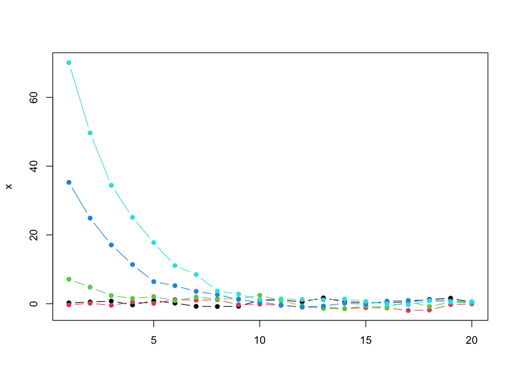

# An example that is not geometrically ergodic

- The canonical example is the Random Walk ($Z_n \sim N(0,1)$)
  $$X_n = X_{n-1} + \sqrt{h} Z_n$$
- This does not even have an equilibrium distribution!
- If $X_0 = x$ then marginally
  $$X_n \sim N(x, nh)$$
- **Questions.** (a) How does $\mathbb{E}[X_n]$ depend on $n$? (b) What about $\text{Var}[X_n]$?

# 20 simulations of Random Walk, $X_1 = 0$, $h = 1$, $N = 50$

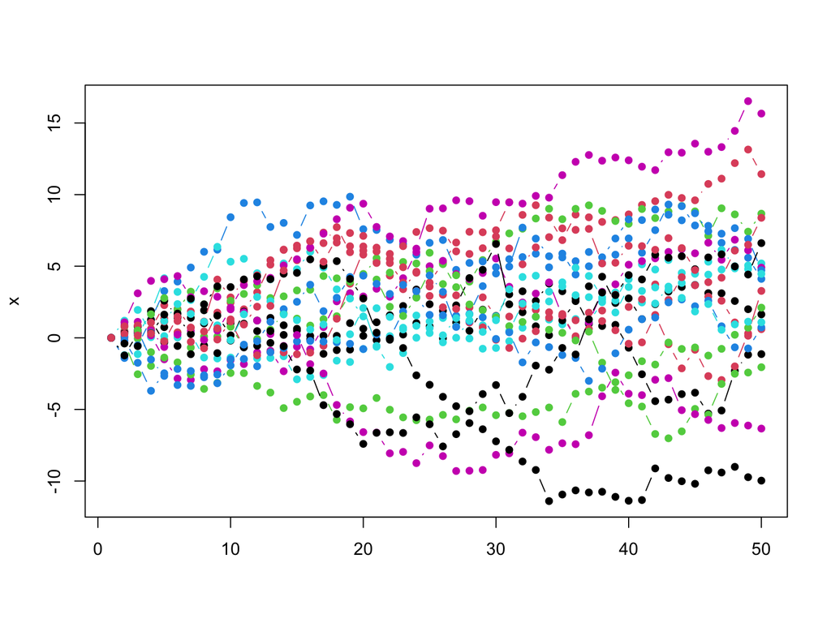

# What about the Random Walk Metropolis?

- The theory essentially says that if $\pi$ has `lighter than exponential tails’, the Markov chain will be geometrically ergodic
- So for Gaussians & Laplace distributions, we should converge quickly
- For heavy-tailed distributions (e.g. Cauchy) it is not Geometrically ergodic

# Lack of GE and practical performance (e.g. traceplots)

- There are essentially two scenarios in which a Metropolis–Hastings algorithm is not geometrically ergodic
  1. In some part of $E$ the acceptance rate gets arbitrarily close to $0$
     $$\text{ess}\inf_{x \in E} \int \alpha(x,y)Q(x,dy) = 0$$
  2. In some parts of $E$ the chain exhibits ‘random walk behaviour’
- If 1 happens the traceplot shows the chain getting stuck
- If 2 happens the traceplot shows the chain meandering aimlessly (see Cauchy example)

# Example of sticking chain (Not typical of RWM, but other MH algorithms)

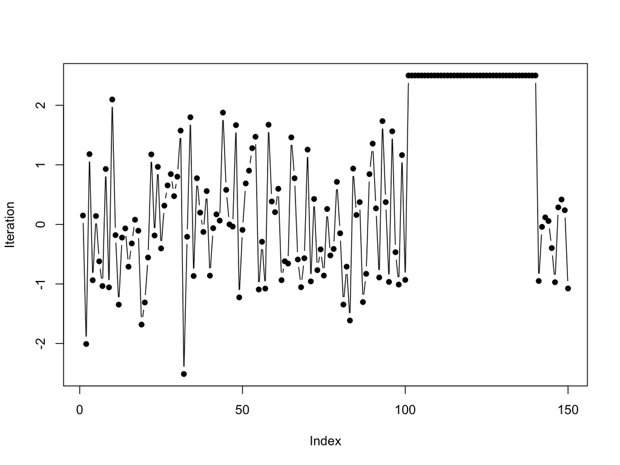

# RWM, Cauchy target

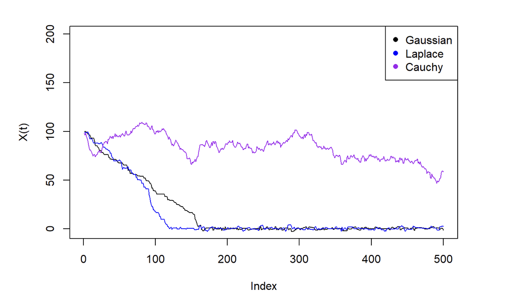

# Establishing geometric ergodicity

- The standard approach is ‘drift and minorisation’
- *(Essentially)* we construct a *Lyapunov function* $V : E \to [1,\infty)$ with compact level sets and $\mathbb{E}_\pi[V]<\infty$, such that for some $\lambda < 1$ the geometric *drift* condition
  $$\mathbb{E}[V(X_{n+1})|X_n = x] \leq \lambda V(x)$$
  is satisfied for all $x$ outside of some compact set $C \subset E$.
- It can be shown that this implies geometric ergodicity in many ways
  - Using a probabilistic coupling and using the coupling inequality for TV distance (e.g. Roberts & Rosenthal, 2004)
  - Constructing a $V-$ norm distance between probabiilties, equivalent to TV, showing that drift condition implies a contraction in this distance + applying Banach fixed point theorem (Hairer & Mattingley, 2011)
- Also called *Harris’ theorem* for Markov chains (Hairer & Mattingley, 2011)
- The classical textbook reference is *Markov chains & Stochastic Stability* (Meyn & Tweedie, 1993)
- **Remark.** In general ‘compact’ -> ‘small’, a slightly different but often overlapping concept, which I will not cover explicitly here

# Example: the AR(1) process

- Consider the chain
  $$X_{n+1} = 0.5 X_n + \xi_{n+1},$$
  where $\xi_{n+1} \sim N(0,1)$
- Choose $V(x) := \max(1, \|x\|)$
- Then for large enough $\|X_n\|$
  $$V(X_{n+1}) = \max( 1, \|X_{n+1}\|) \approx 0.5\|X_n\| + \|\xi_{n+1}\|
  \leq (0.5+\epsilon)\|X_i\|$$
  *(argument can be made rigorous in various ways)*
- **Note:** It’s not usually this easy!
  - Part of the skill comes in choosing the right $V$ (natural + something we can do calculations with)
  - In Metropolis–Hastings making assumptions on $\pi$ to deal with $\alpha(x,y)$ is a technical challenge

# A functional analytic perspective (1)

- For $\pi$-reversible chains Geometric ergodicity in TV distance $\iff$ existence of a positive **absolute spectral gap**
- First let $\pi(f) := \mathbb{E}_\pi[f]$ for $f \in L^2(\pi) :=\{g :E \to \mathbb{R} ; \int g(x)^2\pi(dx) < \infty\}$
- Then define the Markov operator
  $$Pf(x) := \int f(y) P(x,dy)$$
- The Markov chain has a positive absolute spectral gap if
  $$\|P - \pi\| < 1$$
  where $\|v\|^2 := \int v(x)^2\pi(dx)\|$ and $\|P\| := \sup_{\|v\| = 1}\|Pv\|$

# A functional analytic perspective (2)

- When $P$ is a positive operator (cf ‘lazy’ chain) on $L^2(\pi)$ this can be established by showing that this variational quantity is positive
  $$\text{Gap}(P) := \inf_{\|f\| = 1}\langle f, (I-P)f \rangle$$
  where $\langle f,g\rangle := \int f(x)g(x)\pi(dx)$
- When $P$ is a finite matrix this is just $1-\lambda_2$ *(one minus 2nd largest eigenvalue)*
- More generally it can also be written
  $$\text{Gap}(P)
  := \inf_{\|f\| = 1}\frac{1}{2}\int (f(y) - f(x))^2 \pi(dx)P(x,dy)
  = 1- \text{Corr}(f(X_n), f(X_{n+1}))$$
- ‘Expected squared jump distance’ or ‘worst case 1st order auto-correlation’
- It can be upper/lower bounded using tools from analysis (e.g. Poincare inequalities, conductance, canonical paths etc.)

# Burn in: a more practical approach to the bias problem

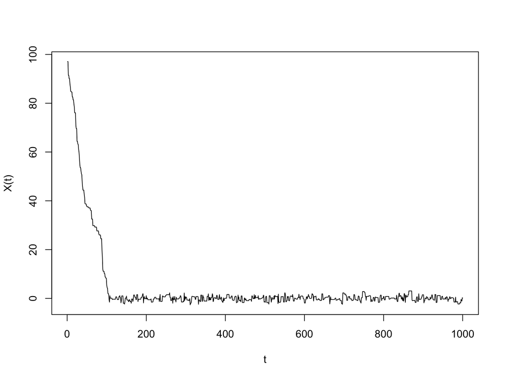

# Burn in: the main idea

- Burn in (or less frequently *warm up*) just means discarding the initial portion of the chain
- This will reduce the bias of the resulting estimator
- One can equivalently adapt our MCMC estimator to be
  $$\tilde{f}_N = \frac{1}{N} \sum_{t = m+1}^{N+m} f(X_t),$$
  where the first $m$ samples are discarded as burn in
- We can often judge how much to discard through trace plots
- **Question.** *What is the problem with using trace plots to decide on burn in in high dimensions?*

# Burn in in general

- We cannot assess the trace plot for every single parameter of interest. But we can do several pragmatic things:
  - Have some kind of blanket rule, such as ‘discard the first 50% of the chain’
  - Examine trace plots of some suitable summaries, e.g. $\log\pi(X_t)$
  - Plot the running averages and check that these have stabilised
- There are many other ‘rules of thumb’ among practitioners and various diagnostics (e.g. $\hat{R}$)
- In many cases a combination of these is a good practical way to reduce bias, and is usually done

# Part 3: Assessing Variance

# Assessing variance

- The variance of $\tilde{f}_N$ is
  $$\text{Var}(\tilde{f}_N) = \text{Var} \left( \frac{1}{N} \sum_{i=1}^N
  f(X_i) \right) = \frac{1}{N^2}\text{Var}\left( \sum_{i=1}^N f(X_i)
  \right)$$
- Because $\text{Var}(f) = \text{Cov}(f,f)$, we can write
  $$\text{Var}(\tilde{f}_N) = \frac{1}{N^2} \text{Cov}\left(\sum_{i=1}^N
  f(X_i), \sum_{i=1}^N f(X_i) \right)$$
- Recalling that $\text{Cov}(f_1 + f_2,f_3) = \text{Cov}(f_1,f_3) + \text{Cov}(f_2,f_3)$ (and similarly for 2nd argument) we can write this as
  $$\frac{1}{N^2} \left( \sum_{i=1}^N\text{Var}(f(X_i)) + 2 \sum_{i<j}
  \text{Cov}\left( f(X_i), f(X_j) \right) \right)$$
- If $X_1 \sim \pi$ then we can go even further since marginally $X_i \sim \pi$ for all $i$, meaning
  $$\text{Var}\left( \tilde{f}_N \right) = \frac{1}{N} \left(
  \text{Var}(f(X_1)) + 2 \sum_{k=2}^N \left( \frac{N-k+1}{N} \right)
  \text{Cov}\left( f(X_1), f(X_k) \right) \right)$$
- **Question.** *How does this relate to the variance under iid sampling from $\pi$?*

# Returning to our intuition of things *not working well* in the RWM

- When $h$ is too small, nearby points will be similar, meaning
  $$\text{Cov}(f(X_1),f(X_k)) \gg 0$$
  for many values of $k$.
- When $h$ is too large and the first $k$ proposals are all rejected then
  $$\text{Cov}(f(X_1),f(X_k)) = \text{Var}(f(X_1))$$
  the maximum possible value
- **Question.** What will happen to $\text{Var}(\tilde{f}_N)$ in either of these two cases?

# The asymptotic variance

- In practice $X_1$ is not from $\pi$
- But imagining $X_1 \sim \pi$ we can define the limiting quantity
  $$\nu(P,f) := \lim_{N \to \infty}N \text{Var}[\tilde{f}_N]$$
- This is called the **asymptotic variance**
- We often compare MCMC algorithms $P_1$ and $P_2$ by comparing $\nu(P_1,f)$ and $\nu(P_2,f)$
- **Question.** Why do we multiply $\text{Var}[\tilde{f}_N]$ by $N$ here?

# A Markov chain CLT

- If $P$ is $\pi$-reversible and geometrically ergodic in TV, and $\mathbb{E}_\pi[f^2]<\infty$, then as $N\to\infty$
  $$\sqrt{N}(\tilde{f}_N - \mathbb{E}_\pi[f]) \overset{d}{\to} N(0,
  \nu(P,f))$$
- This enables the construction of asymptotically valid confidence intervals for MCMC estimators

# Peskun–Tierney orderings

- Peskun (1973, finite state) & Tierney (1998, general state) define the partial ordering on Markov kernels
  $$P_1 \succeq_p P_2 \iff P_1(x,A \cap \{x\}^c) \geq P_2(x,A\cap\{x\}^c)$$
  for all $x \in E$, $A \in \mathcal{E}$.
- *Off-diagonal domination:* $P_1$ always has a larger chance of moving away from the current state than $P_2$
- **Peskun’s theorem.** If $P_1$ and $P_2$ are $\pi$-reversible and $P_1 \succeq_p P_2$, then
  $$\nu(P_1,f) \leq \nu(P_2,f)$$
  for all $f \in L^2(\pi)$.
- **Proof:** Write $P(\beta) := \beta P_1 + (1-\beta)P_2$, show $\partial_\beta \nu(P(\beta),f) \leq 0$ (proof uses e.g. spectral theorem)

# Peskun’s theorem in MCMC

- Consider two Metropolis–Hastings style kernels
  $$\begin{aligned}
  P_1(x,dy) &= \alpha_1(x,y)Q(x,dy) + r_1(x)\delta_x(dy)
  \\
  P_2(x,dy) &= \alpha_2(x,y)Q(x,dy) + r_2(x)\delta_x(dy)
  \end{aligned}$$
  where $r_i(x) := \int [1-\alpha_i(x,y)]Q(x,dy)$ is the *average rejection probability* at state $x$
- These are two algorithms with the same $Q$ but **different acceptance rate functions**
- Letting $\rho(x,y) := \frac{\pi(dy)Q(y,dx)}{\pi(dx)Q(x,dy)}$, two valid choices are
  - *Metropolis* $\alpha_1(x,y) := \min(1,\rho(x,y))$
  - *Barker* $\alpha_2(x,y) := \frac{\rho(x,y)}{1+\rho(x,y)}$
- It can be shown that $\alpha_1(x,y) \geq \alpha_2(x,y)$ for all $x,y \in E$.
- And further that
  $$\alpha_1(x,y) \geq \alpha_2(x,y) \implies P_1 \succeq_p P_2$$
- **Question.** What does this tell us about using Metropolis vs Barker acceptance rates?

# The MCMC effective sample size

- Note that for the ordinary Monte Carlo estimator $\hat{f}_N$, we have
  $$\text{Var}(\hat{f}_N) = \frac{\text{Var}_\pi(f(X))}{N}$$
- This means
  $$\frac{\text{Var}(\tilde{f}_N)}{\text{Var}(\hat{f}_N)} = 1 + 2
  \sum_{k=2}^N \left( \frac{N-k}{N} \right) \text{Corr}\left( f(X_1),
  f(X_k) \right).$$
- We can simplify further by taking the limit as $N \to \infty$, giving
  $$\lim_{N \to \infty}
  \frac{\text{Var}(\tilde{f}_N)}{\text{Var}(\hat{f}_N)} = 1 + 2
  \sum_{k=2}^\infty \text{Corr}\left( f(X_1), f(X_k) \right).$$

# The effective sample size (in theory)

$$N_{\text{eff}} := \frac{N}{1+2\sum_{k=2}^\infty
\text{Corr}(f(X_1),f(X_k))}.$$

(This is how many independent samples from $\pi$ you would need to get an estimator with the same variance as $\tilde{f}_N$).

- In practice this is estimated using some intelligent heuristics
- It is common to report $N_{\text{eff}}$, or even $N_{\text{eff}}/\text{second}$ (much fairer)
- See the `effectiveSize()` command in the `R` package `CODA`

# Auto-correlation plots are also helpful to compare algorithms/visualise variance

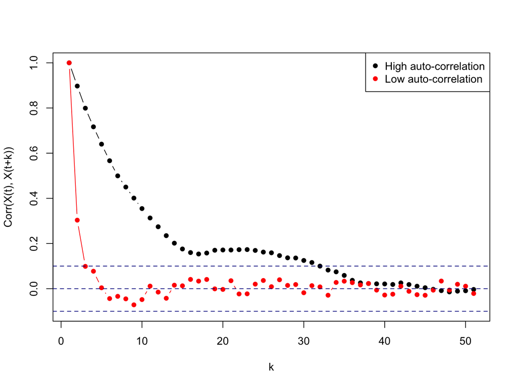

# Part 4: Complexity

# Computational complexity in MCMC

- There are many ways to measure this
- One popular strategy: Cost per iteration $\times$ Convergence rate/Mixing time
- Another is to only discuss the mixing time, since cost per iteration is more problem dependent
- Both costs should be written as a function of dimension $d$
- Generally we desire polynomial time algorithms
  - complexity is a polynomial in $d$ (not exponential)

# The cost per iteration of a Metropolis–Hastings algorithm

- This depends on the algorithm!
- Also depends on $\pi$
- There is the cost of the proposal
  $$Y \sim Q(x,\cdot)$$
  - (for vanilla random walk Metropolis this is $O(d)$)
- Then the cost of accept-reject decision
  $$U \leq \frac{\pi(y)q(y,x)}{\pi(x)q(x,y)}$$
  - (Generally the most expensive part is calculating $\pi$)
  - e.g. if $\pi(x) = \prod_i \pi_i(x_i)$ then cost is $O(d)$ (but this is unrealistic!)

# Convergence rates/mixing times with dimension

- This is a highly active area of study
- Again depends strongly on both the algorithm and $\pi$
- If $\pi$ is suitably ‘nice’ (proper definition omitted) then mixing time of random walk Metropolis is $O(d)$
- This implies Random Walk Metropolis has $O(d^2)$ complexity in some cases
- I prefer to simply say that the mixing time is $O(d)$…

# End of lecture

Tomorrow we discuss more advanced algorithms!